# Tugas 4 MPDW

Andi Fatihatul Fuadiyah

2023-09-21

## White Noise

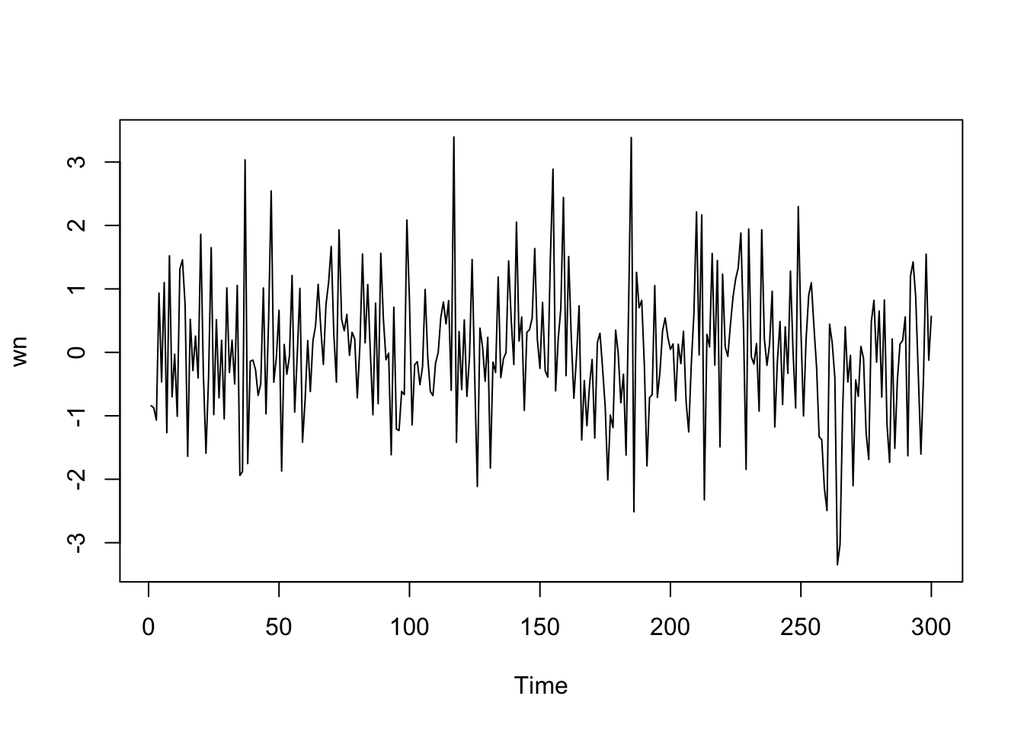

```r
set.seed(1041)
wn <- rnorm(300)
ts.plot(wn)
```

Dapat terlihat bahwa *white noise* tidak memiliki autokorelasi dari ACF. Perhatikan bahwa lag ke-0 adalah korelasi observasi ke-t dengan dirinya sendiri. Nilai korelasi tersebut pasti 1. Sebagai alternatif, lag pertama di plot ACF dapat ditetapkan sebagai 1 (alih-alih 0) dengan menambahkan argumen `xlim(1, lag akhir)`. Plot tersebut dapat disandingkan bersamaan dengan membuat matriks $1 \times 2$ dengan `par(mfrow = c(1,2))`.

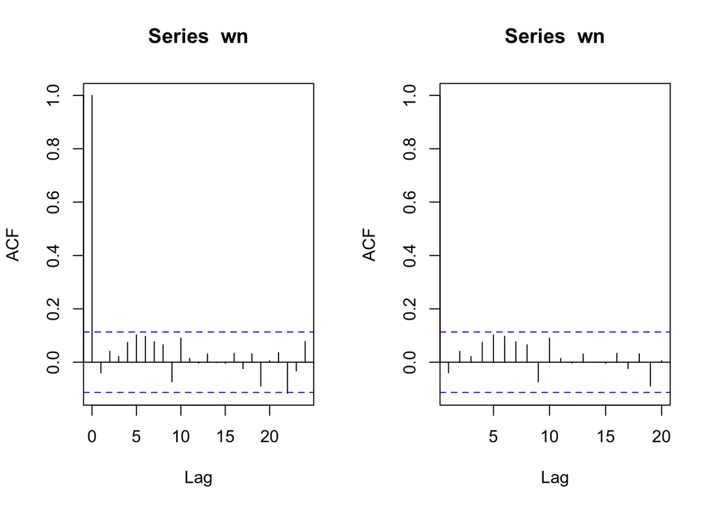

```r
par(mfrow = c(1, 2))
acf(wn)
acf(wn, xlim = c(1, 20))
```

## Proses MA

Proses MA dapat dituliskan sebagai berikut:

$$y_{t} = c + e_t + \theta_{1}e_{t-1} + \theta_{2}e_{t-2} + \dots +
\theta_{q}e_{t-q} = c+{e_t+\sum_{i=1}^p \theta_ie_{t-i}}$$
Terlihat bahwa $e_t$, atau *white noise*, berperan penting dalam pembangkitan proses MA.

```r
set.seed(1041)
ma <- numeric(300)  # Define an object called 'ma' as a numeric vector
ma[1] <- wn[1]
ma[2] <- wn[2]
```

```r
for(i in 3:300){
   ma[i] <- wn[i] + 0.4 * wn[i - 1] + 0.6 * wn[i - 2]
}
ma
```

```
##   [1] -0.8404136204 -0.8750885821 -1.9214695089 -0.0189732190 -0.7341949914
##   [6]  1.4737600936 -1.1045744678  1.6760624963 -0.8509769942  0.6044675208
##  [11] -1.4394341052  0.8930526580  1.3783323677  2.1241873501 -0.4627903744
##  [16]  0.3167668290 -1.0624535541  0.4538679498 -0.4730642656  1.8517144625
##  [21]  0.1721188352 -0.6062458796 -1.2343753355  0.5363544392 -0.5617935468
##  [26]  1.1130350291 -1.1004503184  0.2123293390 -1.4030277705  0.7103711895
##  [31] -0.5403824787  0.6733628339 -0.6130615248  0.9695964361 -1.8179400154
##  [36] -2.0226512014  1.1173812180 -1.6672869628  0.9788945047 -1.2302586052
##  [41] -0.4068901252 -0.8621425014 -0.9327282550  0.4086935529 -0.8613498475
##  [46]  0.7037032639  2.1566793522  0.8378147871  1.2710141221  0.3532218838
##  [51] -1.6471221654 -0.2271609691 -1.4172912682 -0.1216799330  0.9823665965
##  [56] -0.4910686627  0.3214785134  0.4323046313 -1.0312964885 -0.7137934437
##  [61] -0.9654777852 -0.9947597405  0.0446928358  0.1174689396  1.3470000265
##  [66]  1.0646078913  0.6074742801  0.9093954073  1.2884300571  2.5619893385
##  [71]  1.6171657544  0.6478824046  1.9136787746  1.0076099950  1.7041769538
```

[output cut: 45 more lines]

```r
set.seed(1041)
ma1 <- arima.sim(list(order=c(0,0,2), ma=c(0.4,0.6)), n=300)
ma1
```

```
## Time Series:
## Start = 1
## End = 300
## Frequency = 1
##   [1] -1.9214695089 -0.0189732190 -0.7341949914  1.4737600936 -1.1045744678
##   [6]  1.6760624963 -0.8509769942  0.6044675208 -1.4394341052  0.8930526580
##  [11]  1.3783323677  2.1241873501 -0.4627903744  0.3167668290 -1.0624535541
##  [16]  0.4538679498 -0.4730642656  1.8517144625  0.1721188352 -0.6062458796
##  [21] -1.2343753355  0.5363544392 -0.5617935468  1.1130350291 -1.1004503184
##  [26]  0.2123293390 -1.4030277705  0.7103711895 -0.5403824787  0.6733628339
##  [31] -0.6130615248  0.9695964361 -1.8179400154 -2.0226512014  1.1173812180
##  [36] -1.6672869628  0.9788945047 -1.2302586052 -0.4068901252 -0.8621425014
##  [41] -0.9327282550  0.4086935529 -0.8613498475  0.7037032639  2.1566793522
##  [46]  0.8378147871  1.2710141221  0.3532218838 -1.6471221654 -0.2271609691
##  [51] -1.4172912682 -0.1216799330  0.9823665965 -0.4910686627  0.3214785134
```

[output cut: 49 more lines]

### Plot Time Series

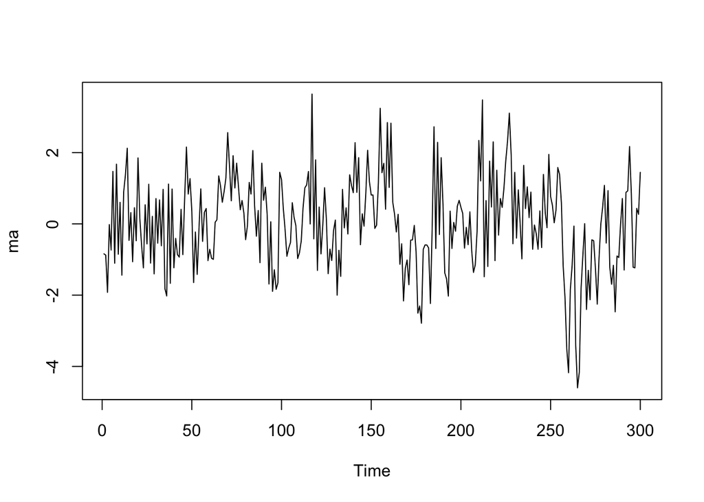

```r
ts.plot(ma)
```

### Plot ACF

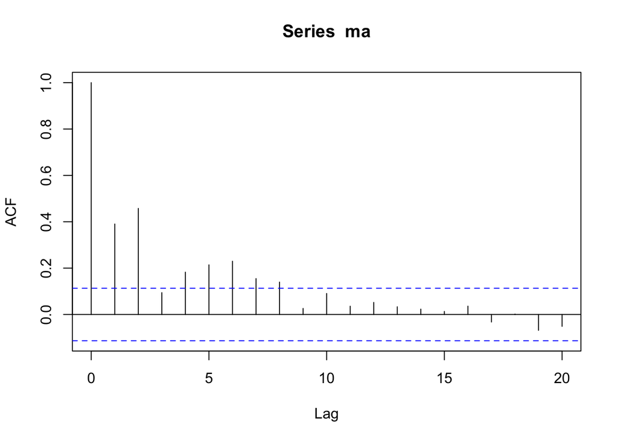

```r
acf(ma,lag.max = 20)
```

### Plot PACF

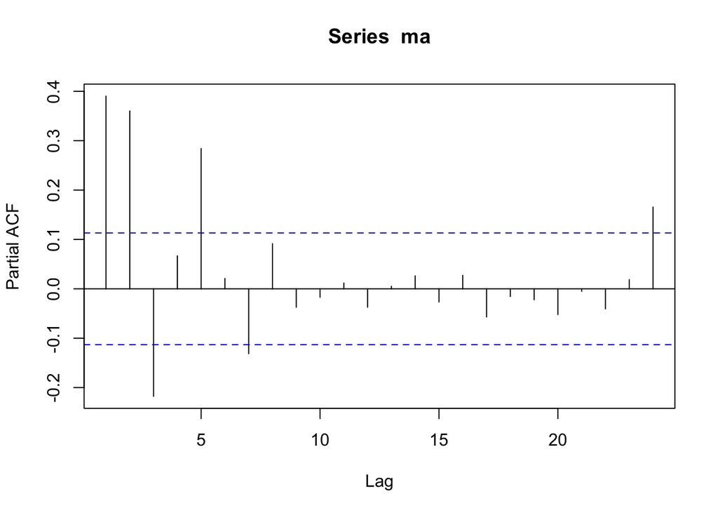

```r
pacf(ma)
```

Berdasarkan plot PACF tersebut, terlihat bahwa plot PACF cenderung *tails off* dan membentuk gelombang sinus

### Plot EACF

```r
TSA::eacf(ma)
```

```
## AR/MA
##   0 1 2 3 4 5 6 7 8 9 10 11 12 13
## 0 x x o x x x x x o o o  o  o  o
## 1 x x x o o o o x o o o  o  o  o
## 2 x o x o o x o o x o o  o  o  o
## 3 x o x o x o o o o o o  o  o  o
## 4 x x x x x o o o o o o  o  o  o
## 5 o x x o x o o o o o o  o  o  o
## 6 x x o o o o o o o o o  o  o  o
## 7 x o x o o o o o o o o  o  o  o
```

### Scatterplot Antar Lag

#### Korelasi antara $Y_t$ dengan $Y_{t-1}$

```r
#Yt
yt_ma <- ma[-1]
yt_ma
```

```
##   [1] -0.8750885821 -1.9214695089 -0.0189732190 -0.7341949914  1.4737600936
##   [6] -1.1045744678  1.6760624963 -0.8509769942  0.6044675208 -1.4394341052
##  [11]  0.8930526580  1.3783323677  2.1241873501 -0.4627903744  0.3167668290
##  [16] -1.0624535541  0.4538679498 -0.4730642656  1.8517144625  0.1721188352
##  [21] -0.6062458796 -1.2343753355  0.5363544392 -0.5617935468  1.1130350291
##  [26] -1.1004503184  0.2123293390 -1.4030277705  0.7103711895 -0.5403824787
##  [31]  0.6733628339 -0.6130615248  0.9695964361 -1.8179400154 -2.0226512014
##  [36]  1.1173812180 -1.6672869628  0.9788945047 -1.2302586052 -0.4068901252
##  [41] -0.8621425014 -0.9327282550  0.4086935529 -0.8613498475  0.7037032639
##  [46]  2.1566793522  0.8378147871  1.2710141221  0.3532218838 -1.6471221654
##  [51] -0.2271609691 -1.4172912682 -0.1216799330  0.9823665965 -0.4910686627
##  [56]  0.3214785134  0.4323046313 -1.0312964885 -0.7137934437 -0.9654777852
##  [61] -0.9947597405  0.0446928358  0.1174689396  1.3470000265  1.0646078913
##  [66]  0.6074742801  0.9093954073  1.2884300571  2.5619893385  1.6171657544
##  [71]  0.6478824046  1.9136787746  1.0076099950  1.7041769538  1.0448150694
```

[output cut: 45 more lines]

```r
#Yt-1
yt_1_ma <- ma[-300]
yt_1_ma
```

```
##   [1] -0.8404136204 -0.8750885821 -1.9214695089 -0.0189732190 -0.7341949914
##   [6]  1.4737600936 -1.1045744678  1.6760624963 -0.8509769942  0.6044675208
##  [11] -1.4394341052  0.8930526580  1.3783323677  2.1241873501 -0.4627903744
##  [16]  0.3167668290 -1.0624535541  0.4538679498 -0.4730642656  1.8517144625
##  [21]  0.1721188352 -0.6062458796 -1.2343753355  0.5363544392 -0.5617935468
##  [26]  1.1130350291 -1.1004503184  0.2123293390 -1.4030277705  0.7103711895
##  [31] -0.5403824787  0.6733628339 -0.6130615248  0.9695964361 -1.8179400154
##  [36] -2.0226512014  1.1173812180 -1.6672869628  0.9788945047 -1.2302586052
##  [41] -0.4068901252 -0.8621425014 -0.9327282550  0.4086935529 -0.8613498475
##  [46]  0.7037032639  2.1566793522  0.8378147871  1.2710141221  0.3532218838
##  [51] -1.6471221654 -0.2271609691 -1.4172912682 -0.1216799330  0.9823665965
##  [56] -0.4910686627  0.3214785134  0.4323046313 -1.0312964885 -0.7137934437
##  [61] -0.9654777852 -0.9947597405  0.0446928358  0.1174689396  1.3470000265
##  [66]  1.0646078913  0.6074742801  0.9093954073  1.2884300571  2.5619893385
##  [71]  1.6171657544  0.6478824046  1.9136787746  1.0076099950  1.7041769538
```

[output cut: 45 more lines]

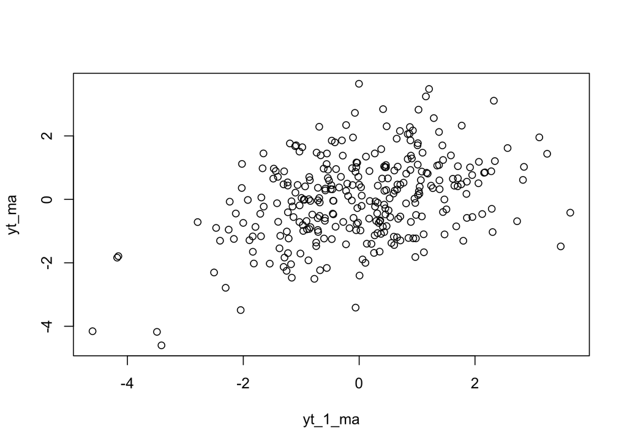

```r
plot(y=yt_ma,x=yt_1_ma)
```

Berdasarkan scatterplot tersebut, terlihat bahwa terdapat hubungan positif antara $Y_t$ dengan $Y_{t-1}$. Hal ini sesuai dengan teori yang ada

```r
cor(yt_ma,yt_1_ma)
```

```
## [1] 0.3912901
```

#### Korelasi antara $Y_t$ dengan $Y_{t-2}$

```r
#Yt
yt_ma2 <- ma[-c(1,2)]
yt_ma2
```

```
##   [1] -1.9214695089 -0.0189732190 -0.7341949914  1.4737600936 -1.1045744678
##   [6]  1.6760624963 -0.8509769942  0.6044675208 -1.4394341052  0.8930526580
##  [11]  1.3783323677  2.1241873501 -0.4627903744  0.3167668290 -1.0624535541
##  [16]  0.4538679498 -0.4730642656  1.8517144625  0.1721188352 -0.6062458796
##  [21] -1.2343753355  0.5363544392 -0.5617935468  1.1130350291 -1.1004503184
##  [26]  0.2123293390 -1.4030277705  0.7103711895 -0.5403824787  0.6733628339
##  [31] -0.6130615248  0.9695964361 -1.8179400154 -2.0226512014  1.1173812180
##  [36] -1.6672869628  0.9788945047 -1.2302586052 -0.4068901252 -0.8621425014
##  [41] -0.9327282550  0.4086935529 -0.8613498475  0.7037032639  2.1566793522
##  [46]  0.8378147871  1.2710141221  0.3532218838 -1.6471221654 -0.2271609691
##  [51] -1.4172912682 -0.1216799330  0.9823665965 -0.4910686627  0.3214785134
##  [56]  0.4323046313 -1.0312964885 -0.7137934437 -0.9654777852 -0.9947597405
##  [61]  0.0446928358  0.1174689396  1.3470000265  1.0646078913  0.6074742801
##  [66]  0.9093954073  1.2884300571  2.5619893385  1.6171657544  0.6478824046
##  [71]  1.9136787746  1.0076099950  1.7041769538  1.0448150694  0.3965209712
```

[output cut: 45 more lines]

```r
#Yt-2
yt_2_ma <- ma[-c(299,300)]
yt_2_ma
```

```
##   [1] -0.8404136204 -0.8750885821 -1.9214695089 -0.0189732190 -0.7341949914
##   [6]  1.4737600936 -1.1045744678  1.6760624963 -0.8509769942  0.6044675208
##  [11] -1.4394341052  0.8930526580  1.3783323677  2.1241873501 -0.4627903744
##  [16]  0.3167668290 -1.0624535541  0.4538679498 -0.4730642656  1.8517144625
##  [21]  0.1721188352 -0.6062458796 -1.2343753355  0.5363544392 -0.5617935468
##  [26]  1.1130350291 -1.1004503184  0.2123293390 -1.4030277705  0.7103711895
##  [31] -0.5403824787  0.6733628339 -0.6130615248  0.9695964361 -1.8179400154
##  [36] -2.0226512014  1.1173812180 -1.6672869628  0.9788945047 -1.2302586052
##  [41] -0.4068901252 -0.8621425014 -0.9327282550  0.4086935529 -0.8613498475
##  [46]  0.7037032639  2.1566793522  0.8378147871  1.2710141221  0.3532218838
##  [51] -1.6471221654 -0.2271609691 -1.4172912682 -0.1216799330  0.9823665965
##  [56] -0.4910686627  0.3214785134  0.4323046313 -1.0312964885 -0.7137934437
##  [61] -0.9654777852 -0.9947597405  0.0446928358  0.1174689396  1.3470000265
##  [66]  1.0646078913  0.6074742801  0.9093954073  1.2884300571  2.5619893385
##  [71]  1.6171657544  0.6478824046  1.9136787746  1.0076099950  1.7041769538
```

[output cut: 45 more lines]

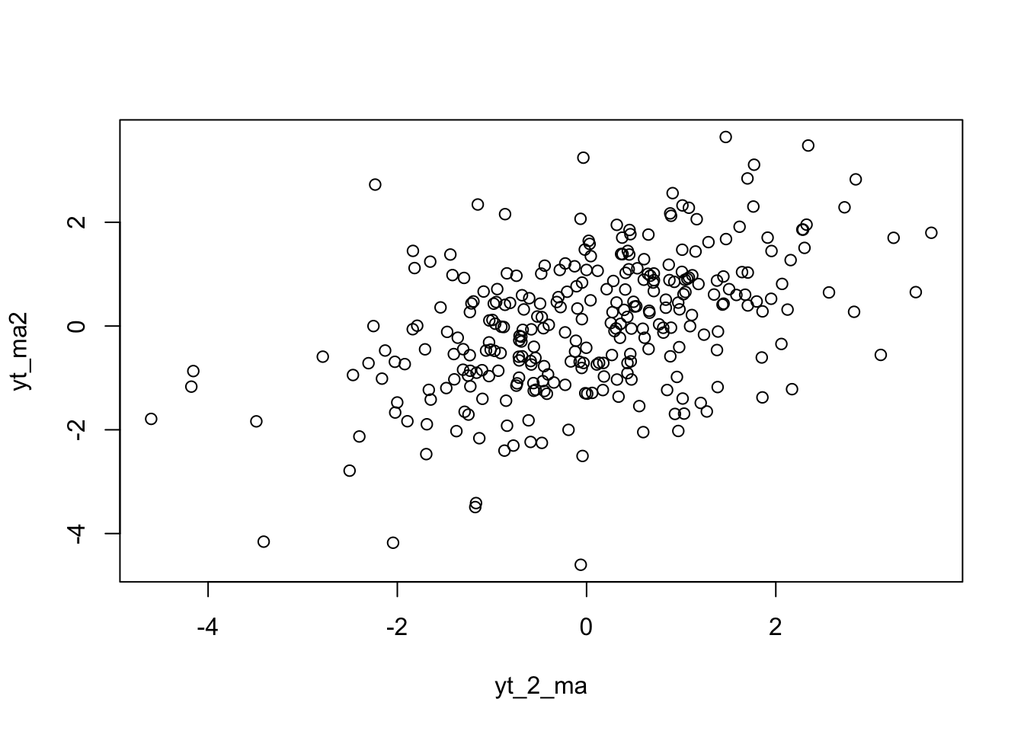

```r
plot(y=yt_ma2,x=yt_2_ma)
```

```r
cor(yt_ma2,yt_2_ma)
```

```
## [1] 0.4592058
```